# Índice de Desarrollo Humano

Técnicas Estadísticas con Información Imprecisa

Lucía Guastoni & Sergi Fornés

En este trabajo se quiere analizar el Índice de Desarrollo Humano (IDH) de todos los países en 2019 desde una perspectiva de información borrosa.  
Primero se crea el IDH clásico para cada país. Este IDH está creado a partir de diferentes métricas macroeconómicas: (1) Esperanza de vida, (2) años de educación y (3) renta nacional bruta per cápita del país. Existen errores en su medición ya que se tratan de métricas macroeconómicas y además no expresan a la perfección ni la salud, ni el nivel de educación, ni el nivel de vida de los países, por lo que se fuzzifican estas métricas y se crea el IDH borroso para cada país. Finalmente se analizan los índices borrosos con técnicas de información imprecisa.

# Datos

Se utilizan dos fuentes de datos diferentes: (1) `hdi.csv` y (2) `population.csv`.

El archivo `hdi.csv` se ha obtenido del [Informe sobre Desarrollo Humano 2020](http://hdr.undp.org/sites/default/files/hdr2020_es.pdf) del Programa de las Naciones Unidas para el Desarrollo. Contiene información sobre las métricas macroeconómicas utilizadas para la creación del IDH de 189 países:

- `Country`: Nombre del país.
- `Life expectancy at birth`: Esperanza de vida al nacer.
- `Expected years of schooling`: Años esperados de escolaridad.
- `Mean years of schooling`: Años promedio de escolaridad.
- `Gross national income per capita`: Ingreso nacional bruto per cápita.

Por otro lado, el archivo `population.csv` se ha obtenido del [banco mundial](https://data.worldbank.org/indicator/SP.POP.TOTL) y contiene la población de 264 países y zonas del mundo en 2019 que se usará para la fuzzificación de las métricas macroeconómicas:

- `Country`: Nombre del país o zona.
- `Population`: Población.

En este último archivo faltaba la población de Palestina y Eritrea, por lo que se han añadido manualmente.

# Índice de Desarrollo Humano clásico

Para la creación del IDH clásico se ha usado la metodología del Informe sobre Desarrollo Humano 2020 [Informe sobre Desarrollo Humano 2020](http://hdr.undp.org/sites/default/files/hdr2020_technical_notes.pdf). Esto es una media entre geométrica entre los índices de esperanza de vida, educación y renta nacional creados a partir de los datos del archivo `hdi.csv`. Los índices son creados para que estén entre 0 y 1.

```r
indices <- read_csv2("hdi.csv")

pop <- read_csv2("population.csv")

data <- left_join(indices, pop, by = "Country") %>%
  mutate(indexHealth = (`Life expectancy at birth` - 20) / (85 - 20),
         indexEducation1 = `Expected years of schooling` / 18,
         indexEducation2 = `Mean years of schooling` / 15,
         indexEducation = (indexEducation1 + indexEducation2) / 2,
         indexGNI = (log(`Gross national income per capita`) - log(100)) /
           (log(75000) - log(100)),
         IDH = (indexHealth * indexEducation * indexGNI)^(1/3)) %>%
  arrange(-IDH)
```

Una vez creados los IDH, veamos su distribución y los países con mayor y menor valor.

```r
data %>%
  select(Country, IDH) %>%
  head()
```

| Country | IDH |
| --- | --- |
| Australia | 0.9800787 |
| Ireland | 0.9619741 |
| Sweden | 0.9591166 |
| Iceland | 0.9590384 |
| Norway | 0.9576401 |
| Switzerland | 0.9554992 |

```r
data %>%
  select(Country, IDH) %>%
  tail()
```

| Country | IDH |
| --- | --- |
| Mali | 0.4335173 |
| Burundi | 0.4334116 |
| South Sudan | 0.4326263 |
| Chad | 0.3977989 |
| Central African Republic | 0.3972007 |
| Niger | 0.3937152 |

```r
c(min(data$IDH), max(data$IDH))
```

```
## [1] 0.3937152 0.9800787
```

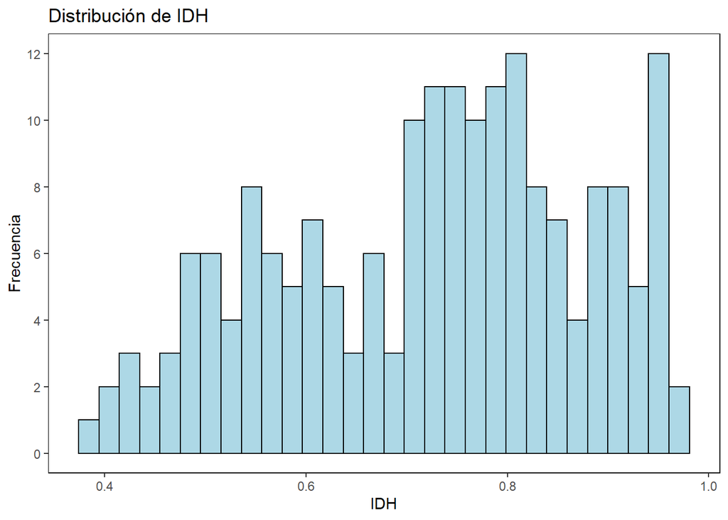

```r
ggplot(data) +
  geom_histogram(aes(x = IDH), color = "black", fill = "lightblue") +
  ggtitle("Distribución de IDH") +
  ylab("Frecuencia") +
  theme(panel.background = element_rect(color = "black", fill = "white"),
        panel.grid = element_blank()) +
  scale_y_continuous(breaks = seq(0, 13, by = 2))
```

Se puede observar como Austrialia, Irlanda, Suecia, Islandia, Noruega y Suiza son los países con mayor IDH, mientras que los países con menor valor del índice son Mali, Burundi, Sudán del Sur, Chad, República Centroafricana y Niger.

También se puede ver como el rango de valores del IDH va de 0.39 hasta 0.98.

# Índice de Desarrollo Humano borroso

A continuación se calcula el IDH borroso a partir de las métricas macroeconómicas fuzzificadas. Para realizar la fuzzificación, se ha considerado que a mayor población del país, más susceptible es la métrica a los errores, por lo que el soporte será mayor. Así que los métricas fuzzificadas serán números borrosos triangulares con core igual al valor crisp, y soporte entre un x% por debajo y un x% por arriba del valor crip. Este x% está entre un 5% y un 15% y depende del logarítmo neperiando de la población del país. Se ha elegido el logarítmo ya que hay unos pocos países con un número de habitantes muy superior a los demás, por lo que con los logarítmos se distribuyen los porcentajes con mayor uniformidad.

Una vez fuzzificadas las métricas macroeconómicas de esperanza de vida, años de educación y renta nacional bruta per cápita de cada país, se calcula el IDH usando la misma metodología que el apartado anterior, aunque esta vez con números borrosos.

```r
data <- data %>%
  mutate(fuzzyPop = 0.05 + 0.1 * (log(Population) - min(log(Population))) /
           (max(log(Population)) - min(log(Population))))

fuzzyLEAB <- list()
fuzzyEYOS <- list()
fuzzyMYOS <- list()
fuzzyGNIPC <- list()
fuzzyIndexHealth <- list()
fuzzyIndexEducation1 <- list()
fuzzyIndexEducation2 <- list()
fuzzyIndexEducation <- list()
fuzzyIndexGNI <- list()
fuzzyIDH <- list()
for(i in 1:nrow(data)) {
  fuzzyLEAB[i] <- as.PiecewiseLinearFuzzyNumber(TriangularFuzzyNumber(
    data$`Life expectancy at birth`[i] * (1 - data$fuzzyPop[i]),
    data$`Life expectancy at birth`[i],
    data$`Life expectancy at birth`[i] * (1 + data$fuzzyPop[i])))
  fuzzyEYOS[i] <- as.PiecewiseLinearFuzzyNumber(TriangularFuzzyNumber(
    data$`Expected years of schooling`[i] * (1 - data$fuzzyPop[i]),
    data$`Expected years of schooling`[i],
    data$`Expected years of schooling`[i] * (1 + data$fuzzyPop[i])))
  fuzzyMYOS[i] <- as.PiecewiseLinearFuzzyNumber(TriangularFuzzyNumber(
    data$`Mean years of schooling`[i] * (1 - data$fuzzyPop[i]),
    data$`Mean years of schooling`[i],
    data$`Mean years of schooling`[i] * (1 + data$fuzzyPop[i])))
  fuzzyGNIPC[i] <- as.PiecewiseLinearFuzzyNumber(TriangularFuzzyNumber(
    data$`Gross national income per capita`[i] * (1 - data$fuzzyPop[i]),
    data$`Gross national income per capita`[i],
    data$`Gross national income per capita`[i] * (1 + data$fuzzyPop[i])))
  fuzzyIndexHealth[i] <- (fuzzyLEAB[[i]] - 20) / (85 - 20)
  fuzzyIndexEducation1[i] <- fuzzyEYOS[[i]] / 18
  fuzzyIndexEducation2[i] <- fuzzyMYOS[[i]] / 15
  fuzzyIndexEducation[i] <- (fuzzyIndexEducation1[[i]] + fuzzyIndexEducation2[[i]]) / 2
  fuzzyIndexGNI[i] <- (fapply(fuzzyGNIPC[[i]],
                              function(x) log(x)) - log(100)) / (log(75000) - log(100))
  fuzzyIDH[i] <- fapply((fuzzyIndexHealth[[i]] *
                           fuzzyIndexEducation[[i]] *
                           fuzzyIndexGNI[[i]]),
                        function(x) x^(1/3))
}
```